# Intelligent Data Analysis Assingment 3

## Francisco de Borja González Glez (EIT)

## Francisco Santos Garcia (EIT)

## Fernando Díaz González (EIT)

## Ricardo García García (EIT)

## Sergio Cámara Braña (MUI)

The goal of this assingment is to perform an analysis of a temporal series and compare the features of the differents methods and models we can apply. We begin by loading the librarys we are using for this assignment.

```r
library(xlsx)
library(plyr)
library(forecast)
library(astsa)
library(tseries)
```

Now, we load our dataset and let us check what happens when you turn your data into time series. Since our data is repeated every 3 months we have to use 4 as a parameter for the frequency:

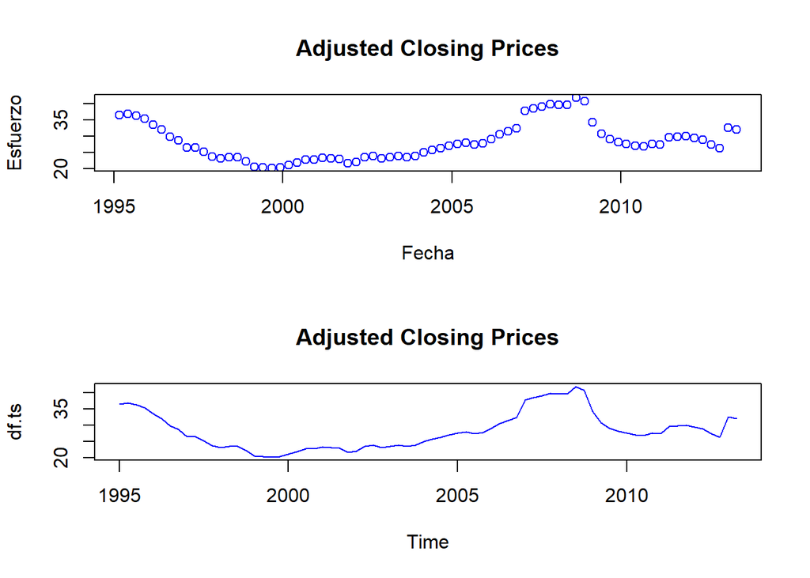

```r
par(mfrow=c(2,1))
df <- read.xlsx(('data_g6.xlsx'),sheetIndex=1)
names(df) <- c('Fecha','Esfuerzo')
plot(df, main="Adjusted Closing Prices", col="blue")
df.ts <- ts(df[,2], frequency=4, start=c(1995,1))
plot(df.ts, main="Adjusted Closing Prices", col="blue")
```

## STATIONARITY OF THE DATA?

We can observe from the previous plot that we do not have a clear trend neither a seasonal component. The series do not look like as stationary but we need to be sure about it in order to make further assumptions. Stationarity means that the mean, variance and autocorrelation structure of a time series do not change over time. We will now use the decompose method in order to see a more detailed description of the topics discussed:

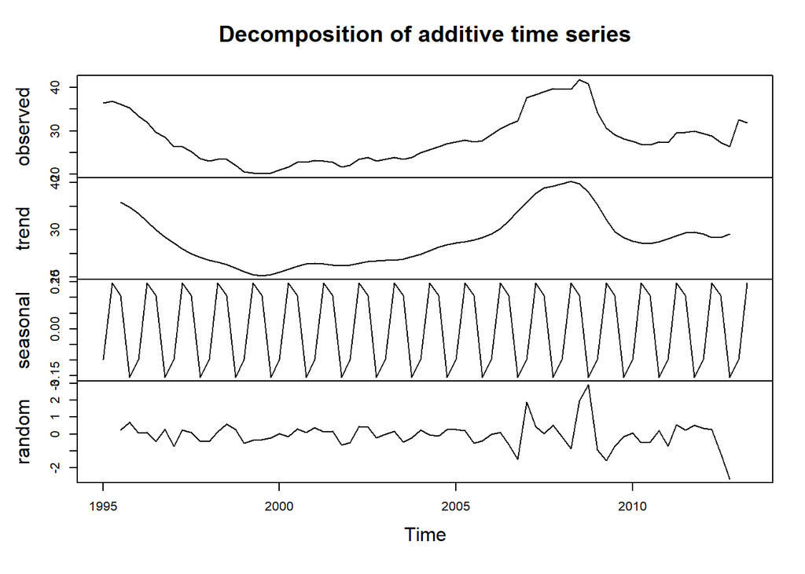

```r
par(mfrow=c(1,1))
decomp.df <- decompose(df.ts)
#decomp.df
plot(decomp.df)
```

Sometimes we can do some transformations to minimize this effects in case we have a multiplicative decomposition where the seasonal efect is higher as the trend increases. We can apply logarithmic or Box-Cox transformations, but in our case we can see that it is not worth it:

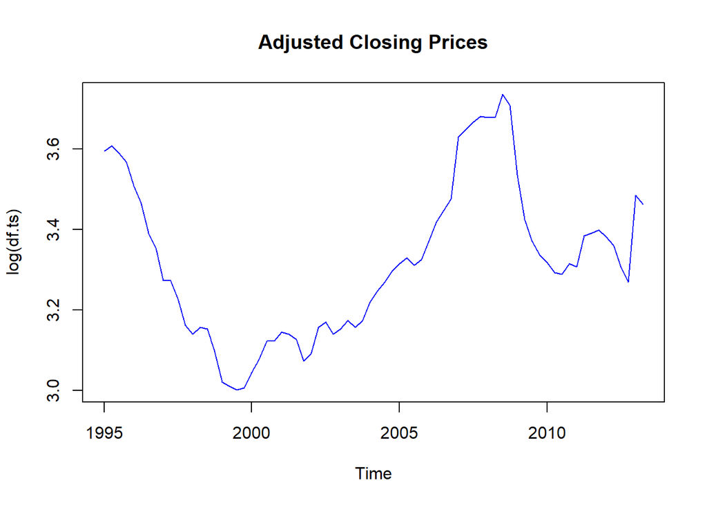

```r
plot(log(df.ts), main="Adjusted Closing Prices", col="blue")
```

In order to check the maths of the lack of stationarity we can group our data by year and calculate the mean values and the variance.

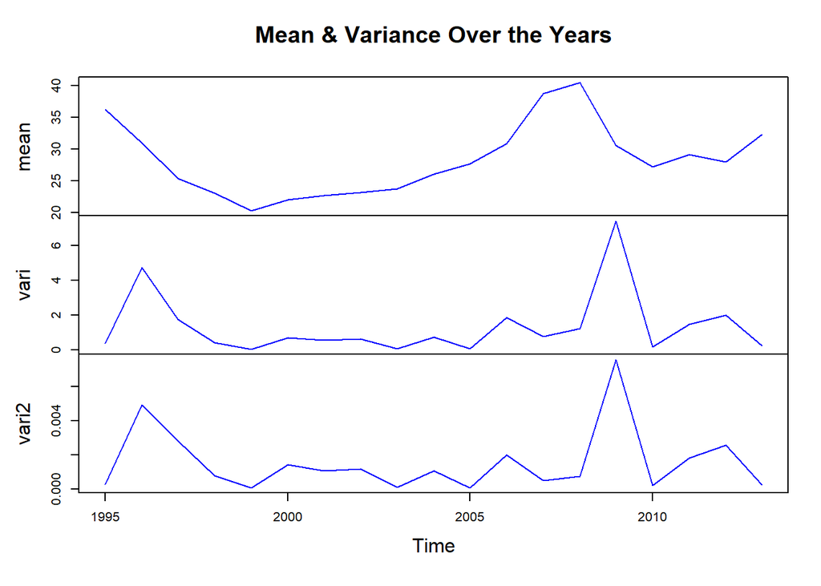

```r
df$year <- substr(df$Fecha,1,4)
df2 <- ddply(df,~year,summarise,mean=mean(Esfuerzo),vari=var(Esfuerzo),vari2 = var(log(Esfuerzo)))
df2.ts <- ts(df2[,c(2,3,4)], frequency=1, start=c(1995))
plot(df2.ts, main="Mean & Variance Over the Years", col="blue")
```

Now, it is more clear that both the mean and the variance change over time and that we do not get any possitive effect from using the log transformation.

## DECOMPOSING AND FORECASTING WITH STL.

Now, we are using another decomposing method similar to the one we used before, splitting the series into seasonal, trend and irregular components:

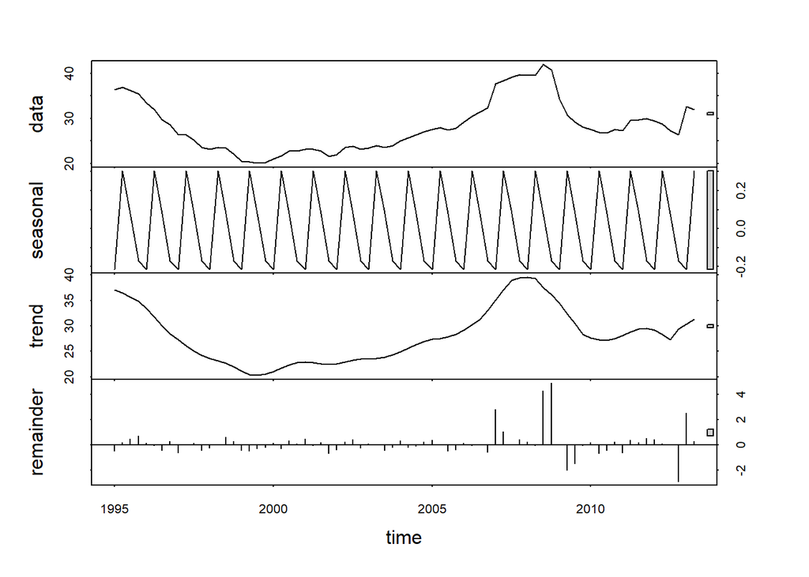

```r
stl1.df <- stl(df.ts,s.window="periodic",  robust = TRUE)
plot(stl1.df)
```

We can do an initial forecast by 2 different methods with our time series already decompossed:

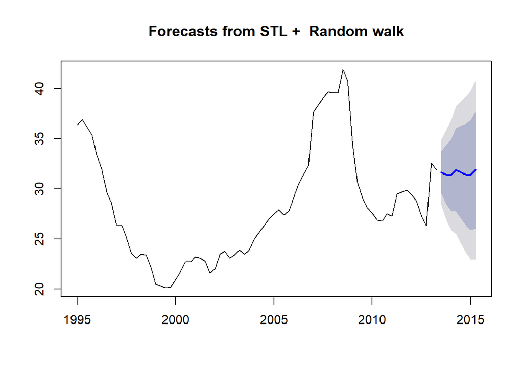

```r
#forecasting with stl()
fcst=forecast(stl1.df, method="naive")
plot(fcst)
```

```r
fcst$mean
```

```
##          Qtr1     Qtr2     Qtr3     Qtr4
## 2013                   31.67638 31.42419
## 2014 31.38212 31.90000 31.67638 31.42419
## 2015 31.38212 31.90000
```

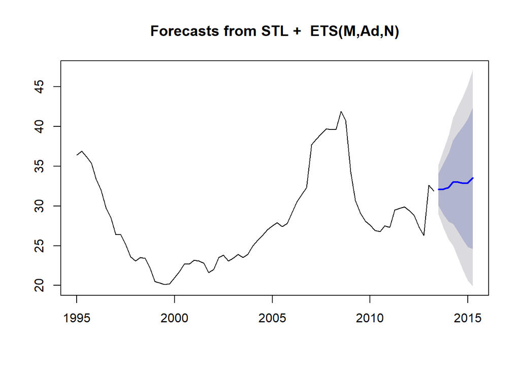

```r
# or
fcst2=forecast(stl1.df, method="ets")
plot(fcst2)
```

```r
fcst$mean
```

```
##          Qtr1     Qtr2     Qtr3     Qtr4
## 2013                   31.67638 31.42419
## 2014 31.38212 31.90000 31.67638 31.42419
## 2015 31.38212 31.90000
```

So, we are facing a problem of additive series since the log transformation did not make any improvement on the variance effects. Let us study now the remainder part and see if it looks like white noise (mean zero and no correlation between its values at different times).

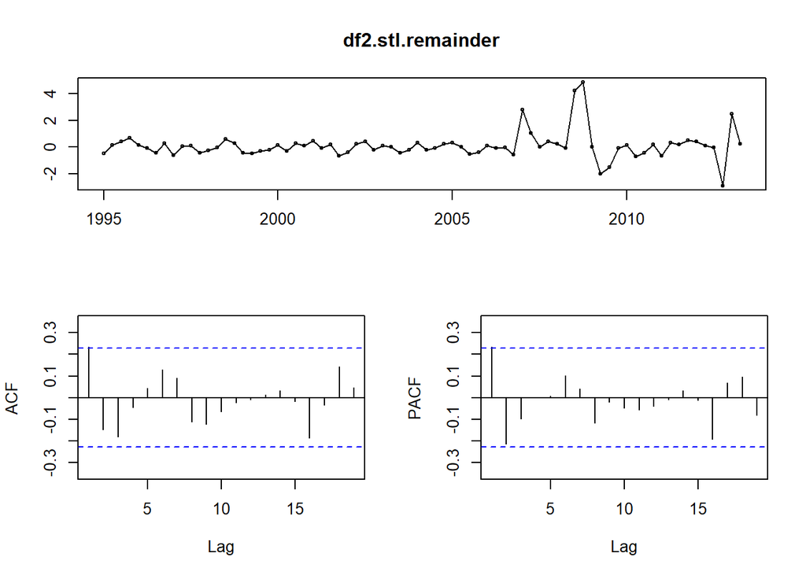

```r
df2.stl.remainder <- stl1.df$time.series[,c("remainder")]
tsdisplay(df2.stl.remainder)
```

Residuals would look like a white noise if we deal with the high crests that may seem as outliers. We have some correlation on the residuals. Let’s see if we can solve this issue by fitting an Arima model.

## ARIMA MODEL

For fitting our arima model, we have to decide firstly if we are using our original data or the logarithmic of it. We have already seen that using the log transformation does not make any improvement, so the simpler, the better:

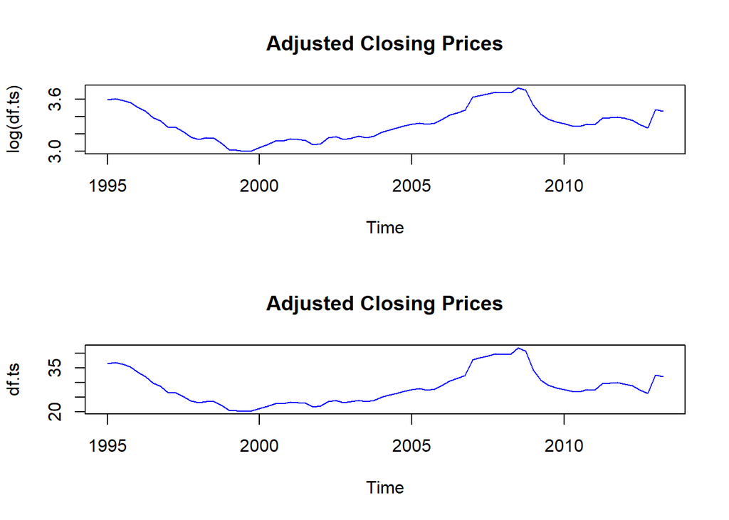

```r
par(mfrow=c(2,1))
plot(log(df.ts), main="Adjusted Closing Prices", col="blue")
plot(df.ts, main="Adjusted Closing Prices", col="blue")
```

```r
par(mfrow=c(1,1))
```

After that we have to think about if we have to consider a seasonal component.

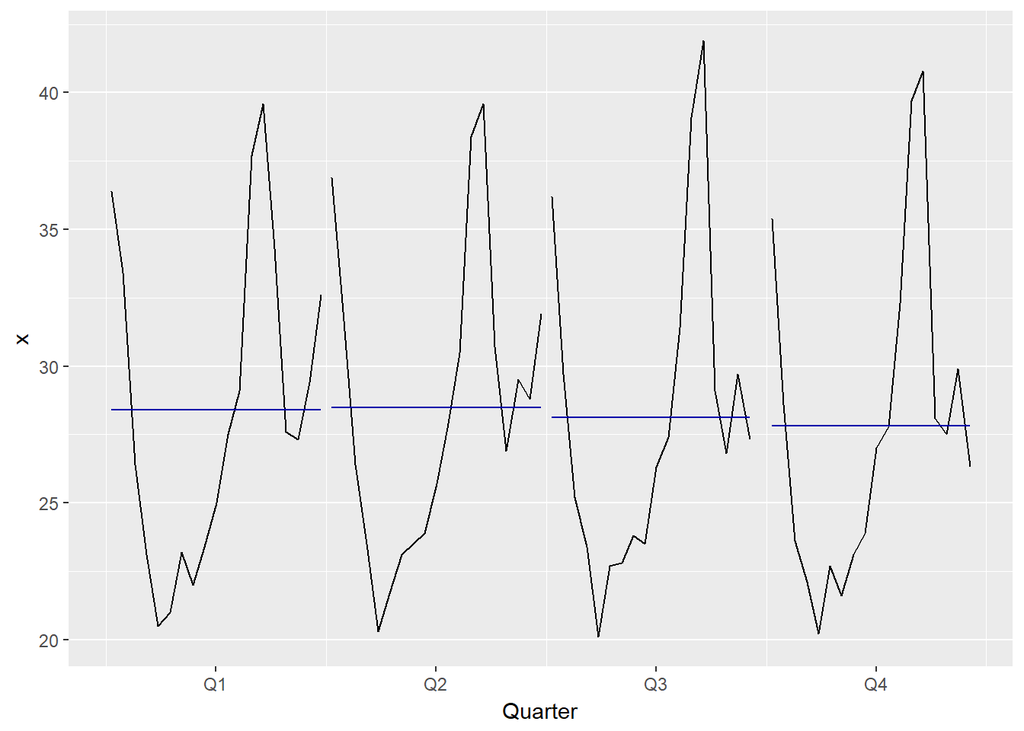

```r
ggmonthplot(df.ts)
```

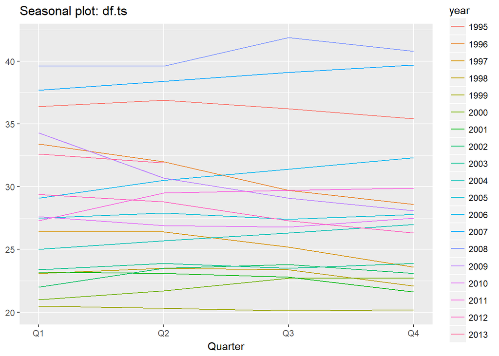

```r
ggseasonplot(df.ts)
```

```r
#tsdisplay(log(df.ts), plot.type = "spectrum")
# par(mfrow=c(1,2))
# seasonplot((df.ts))
# monthplot((df.ts))
```

Seasonplot and monthplot are comented since they are quite similar to the ggplots graphs but they look less nice. From these we can infer that there is not a clear seasonal component since the mean remains constant over the years. Now, we need to make our timeseries stationary and we are using diff method to do so. We have to decide now how many times do we need to diff in order to achieve that seasonarity. There are some automatics methods such as ndiffs() but we will trust the least we are able in automatized methods and we are trying to figure it out by ourselves.

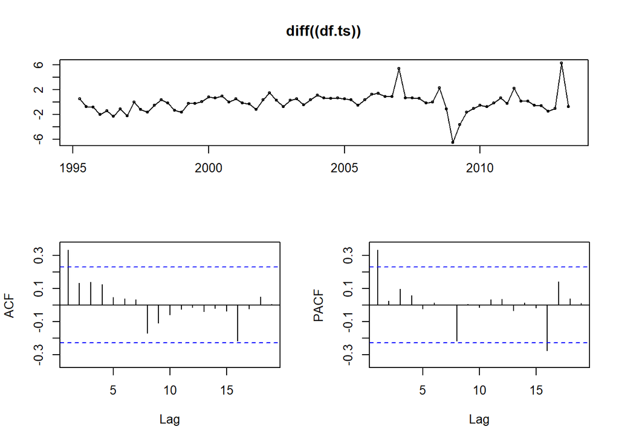

```r
tsdisplay(diff((df.ts)))
```

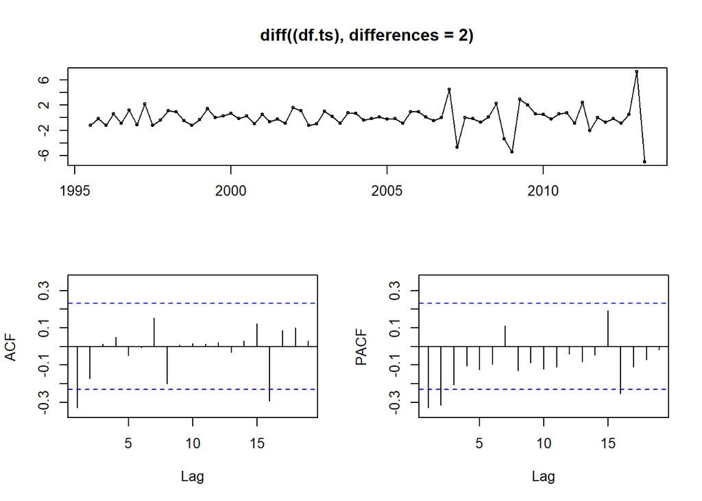

```r
tsdisplay(diff((df.ts), differences = 2))
```

```r
c('TSERIES',var(df.ts),'DIFF-',var(diff(df.ts)),'2DIFF',var(diff(diff(df.ts))))
```

```
## [1] "TSERIES"          "32.448754165124"  "DIFF-"
## [4] "2.63045281582953" "2DIFF"            "3.54197183098592"
```

We can see that the first graph looks more flat thant the second one, and we confirm it by printing out the values of the variance of the original time series and the first and second differenced tseries, since the variance of the second diff is greater than the first one.

Once we know the d parameter of our Arima model (d = 1), we have to search for p and q. We can do this by looking at the acf2 plots:

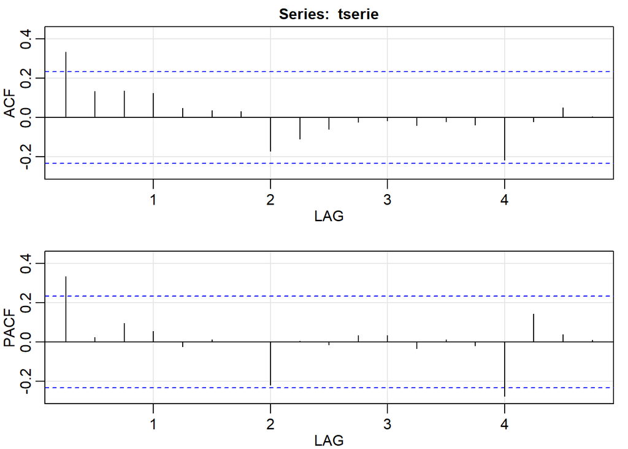

```
##         ACF  PACF
##  [1,]  0.33  0.33
##  [2,]  0.13  0.02
##  [3,]  0.14  0.10
##  [4,]  0.13  0.06
##  [5,]  0.05 -0.02
##  [6,]  0.04  0.01
##  [7,]  0.03  0.00
##  [8,] -0.17 -0.22
##  [9,] -0.11  0.00
## [10,] -0.06 -0.01
## [11,] -0.02  0.03
## [12,] -0.02  0.03
## [13,] -0.04 -0.03
## [14,] -0.02  0.01
## [15,] -0.04 -0.02
## [16,] -0.22 -0.28
## [17,] -0.02  0.14
## [18,]  0.05  0.04
## [19,]  0.01  0.01
```

```r
tserie = diff(df.ts)
acf2(tserie)
```

We will look just athe first spikes of our plot. This is quite opened to personal interpretations. Since we can see kind of exponential decay of the ACF plot after the first spike we are going to try with a (p,d,q) = (1,1,0) model and see what do we get. Other way to do it is trying little by little to adjust all the parameters by try and failure. Remember that we have declined the possible existence of a seasonal component:

```r
df_ari1 = Arima(df.ts, order=c(1,1,0))
summary(df_ari1)
```

```
## Series: df.ts
## ARIMA(1,1,0)
##
## Coefficients:
##          ar1
##       0.3318
## s.e.  0.1095
##
## sigma^2 estimated as 2.337:  log likelihood=-134.13
## AIC=272.26   AICc=272.43   BIC=276.84
##
## Training set error measures:
##                       ME     RMSE      MAE        MPE     MAPE      MASE
## Training set -0.04366259 1.508082 0.935846 -0.1856966 3.199883 0.2896075
##                      ACF1
## Training set -0.001957408
```

After fitting our model we have to do analysis of the residuals to determine the accuracy of our model or if we have to try with other parameters. We will look for normality, and no correlation between our residuals:

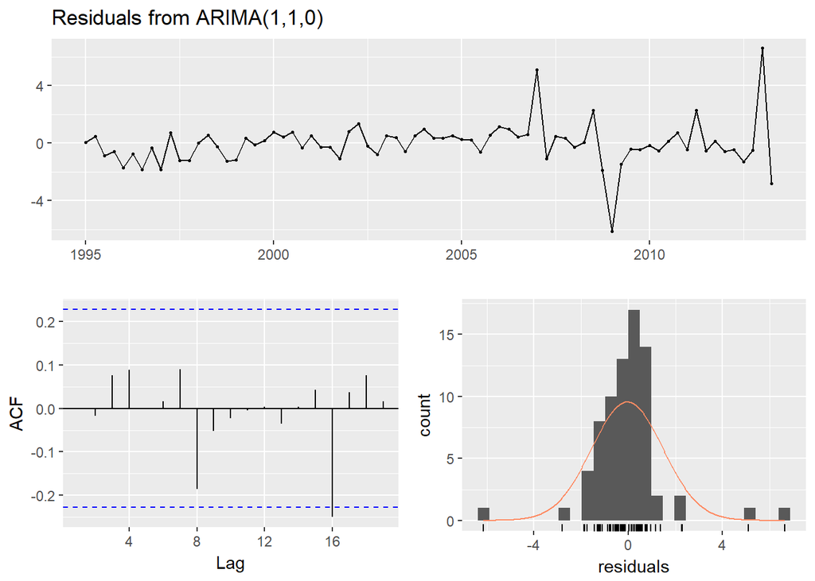

```
##
##  Ljung-Box test
##
## data:  Residuals from ARIMA(1,1,0)
## Q* = 4.7696, df = 7, p-value = 0.6881
##
## Model df: 1.   Total lags used: 8
```

```r
checkresiduals(df_ari1)
```

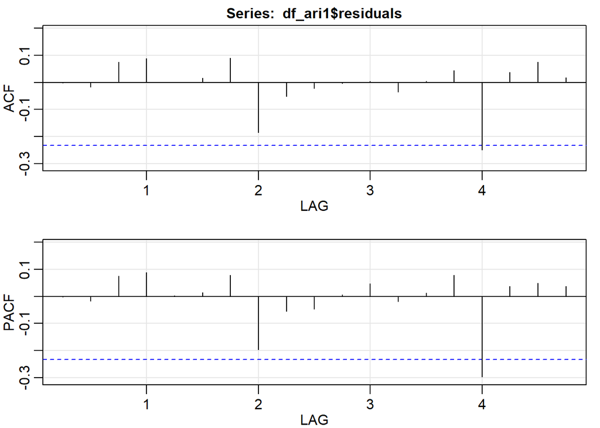

```
##         ACF  PACF
##  [1,]  0.00  0.00
##  [2,] -0.02 -0.02
##  [3,]  0.08  0.08
##  [4,]  0.09  0.09
##  [5,]  0.00  0.00
##  [6,]  0.02  0.01
##  [7,]  0.09  0.08
##  [8,] -0.19 -0.20
##  [9,] -0.05 -0.05
## [10,] -0.02 -0.05
## [11,]  0.00  0.01
## [12,]  0.00  0.05
## [13,] -0.04 -0.02
## [14,]  0.00  0.01
## [15,]  0.04  0.08
## [16,] -0.25 -0.30
## [17,]  0.04  0.04
## [18,]  0.08  0.05
## [19,]  0.02  0.04
```

```r
acf2(df_ari1$residuals)
```

```r
jarque.bera.test(df_ari1$residuals)
```

```
##
##  Jarque Bera Test
##
## data:  df_ari1$residuals
## X-squared = 209.72, df = 2, p-value < 2.2e-16
```

```r
Box.test(df_ari1$residuals, lag=12)
```

```
##
##  Box-Pierce test
##
## data:  df_ari1$residuals
## X-squared = 4.4573, df = 12, p-value = 0.9737
```

The p-value of the box.test and the one we obtained in the ljung-box test do no reject the null hypothesis of independence of our residuals and the jarque bera result suggests that our distribution is not normal, which may be caused by the 4-6 outliers we can see in the plot of the model fitted.

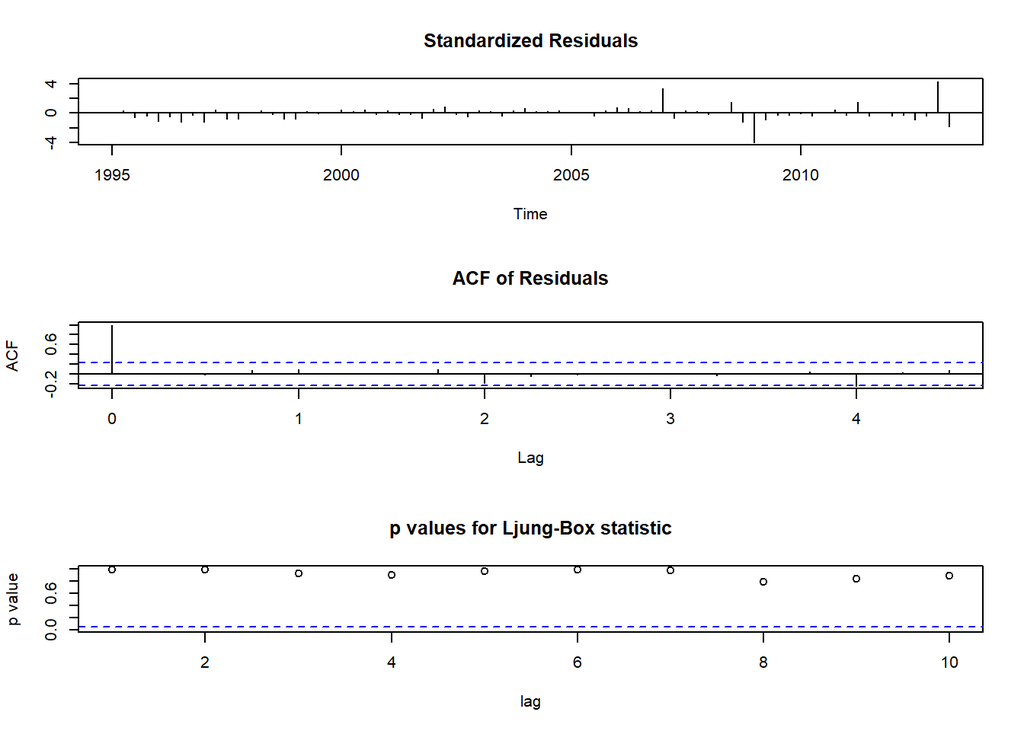

```r
tsdiag(df_ari1)
```

To be sure our model is the best and our assumptions are correct, we can try to fit some new models and see if we get better results.

```r
df_ari2 = Arima(df.ts, order=c(1,1,2))
summary(df_ari2)
```

```
## Series: df.ts
## ARIMA(1,1,2)
##
## Coefficients:
##          ar1      ma1      ma2
##       0.7143  -0.3861  -0.1205
## s.e.  0.2910   0.3128   0.1766
##
## sigma^2 estimated as 2.385:  log likelihood=-133.84
## AIC=275.67   AICc=276.26   BIC=284.84
##
## Training set error measures:
##                       ME     RMSE       MAE        MPE     MAPE      MASE
## Training set -0.03365215 1.501889 0.9223071 -0.1254479 3.154205 0.2854178
##                      ACF1
## Training set -0.002236875
```

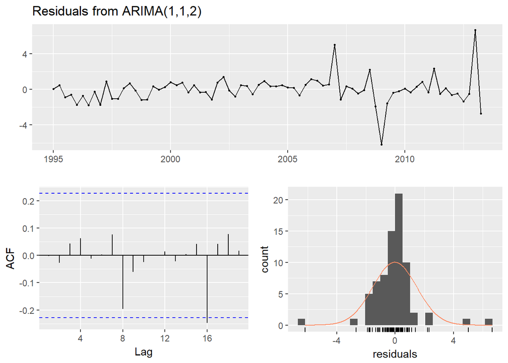

```
##
##  Ljung-Box test
##
## data:  Residuals from ARIMA(1,1,2)
## Q* = 4.3073, df = 5, p-value = 0.5061
##
## Model df: 3.   Total lags used: 8
```

```r
checkresiduals(df_ari2)
```

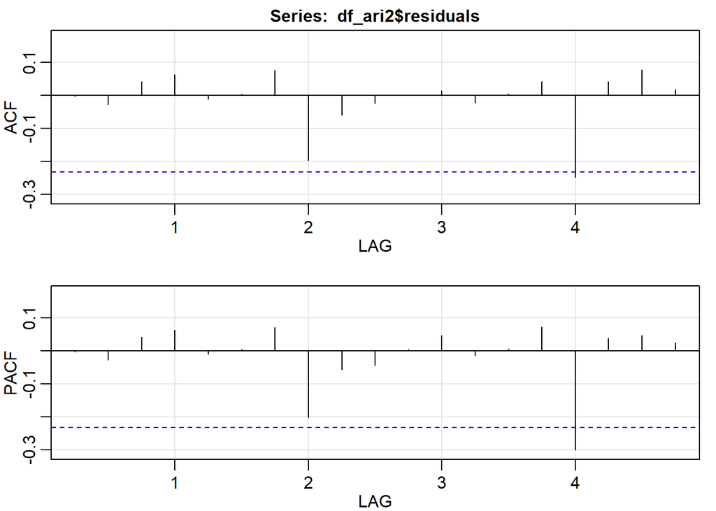

```
##         ACF  PACF
##  [1,]  0.00  0.00
##  [2,] -0.03 -0.03
##  [3,]  0.04  0.04
##  [4,]  0.06  0.06
##  [5,] -0.01 -0.01
##  [6,]  0.00  0.01
##  [7,]  0.08  0.07
##  [8,] -0.20 -0.20
##  [9,] -0.06 -0.06
## [10,] -0.02 -0.04
## [11,]  0.00  0.00
## [12,]  0.01  0.05
## [13,] -0.02 -0.01
## [14,]  0.01  0.01
## [15,]  0.04  0.07
## [16,] -0.25 -0.30
## [17,]  0.04  0.04
## [18,]  0.08  0.05
## [19,]  0.02  0.02
```

```r
acf2(df_ari2$residuals)
```

```r
Box.test(df_ari2$residuals, lag=12)
```

```
##
##  Box-Pierce test
##
## data:  df_ari2$residuals
## X-squared = 4.1048, df = 12, p-value = 0.9815
```

```r
jarque.bera.test(df_ari2$residuals)
```

```
##
##  Jarque Bera Test
##
## data:  df_ari2$residuals
## X-squared = 219.42, df = 2, p-value < 2.2e-16
```

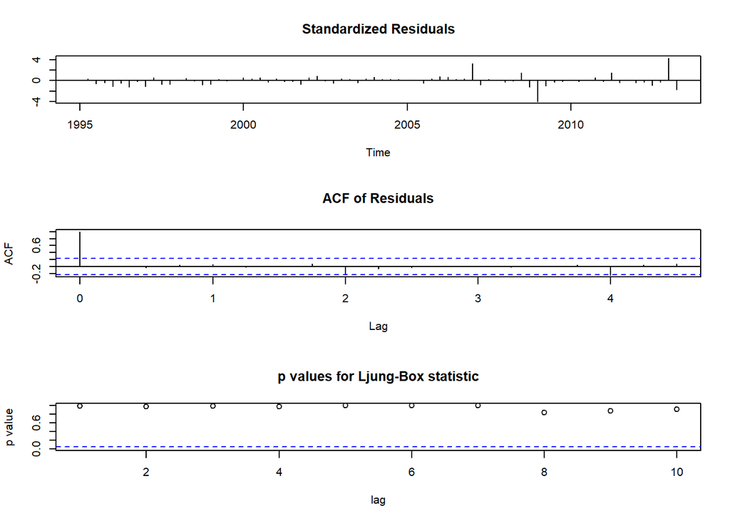

```r
tsdiag(df_ari2)
```

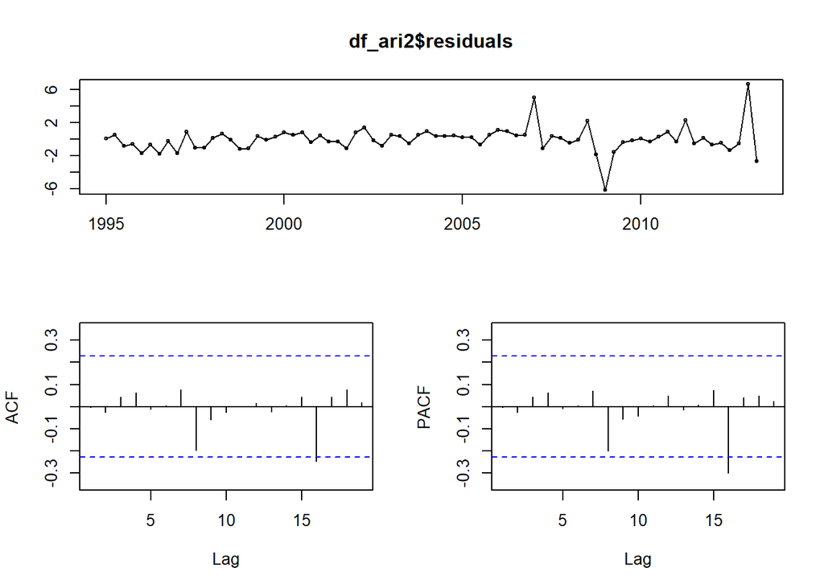

```r
tsdisplay(df_ari2$residuals)
```

In this new model residuals are uncorrelated and the outliers disturb the condition of normality as well. But, this new model apart from having higher parameters (as usual, the simpler the better) is worse than the first one in terms of AICc (the lower, the better) but the usual ML metrics are better now. We can also obtain the parameters in an automatic way:

```r
auto.arima(df.ts)
```

```
## Series: df.ts
## ARIMA(0,1,1)(0,0,2)[4]
##
## Coefficients:
##          ma1    sma1     sma2
##       0.3543  0.1423  -0.3971
## s.e.  0.1125  0.1473   0.1475
##
## sigma^2 estimated as 2.091:  log likelihood=-129.83
## AIC=267.67   AICc=268.25   BIC=276.83
```

```r
df_ari3 = Arima(df.ts, order=c(0,1,1), seasonal = c(0,0,2))
summary(df_ari3)
```

```
## Series: df.ts
## ARIMA(0,1,1)(0,0,2)[4]
##
## Coefficients:
##          ma1    sma1     sma2
##       0.3543  0.1423  -0.3971
## s.e.  0.1125  0.1473   0.1475
##
## sigma^2 estimated as 2.091:  log likelihood=-129.83
## AIC=267.67   AICc=268.25   BIC=276.83
##
## Training set error measures:
##                       ME     RMSE      MAE        MPE     MAPE      MASE
## Training set -0.06154768 1.406267 0.986422 -0.3315947 3.425295 0.3052588
##                    ACF1
## Training set 0.02313018
```

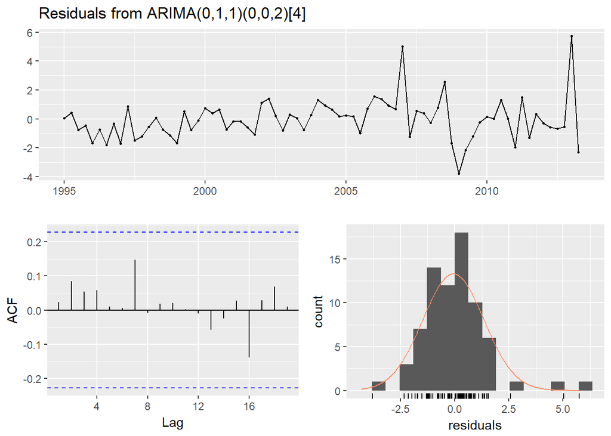

```
##
##  Ljung-Box test
##
## data:  Residuals from ARIMA(0,1,1)(0,0,2)[4]
## Q* = 2.9341, df = 5, p-value = 0.7102
##
## Model df: 3.   Total lags used: 8
```

```r
checkresiduals(df_ari3)
```

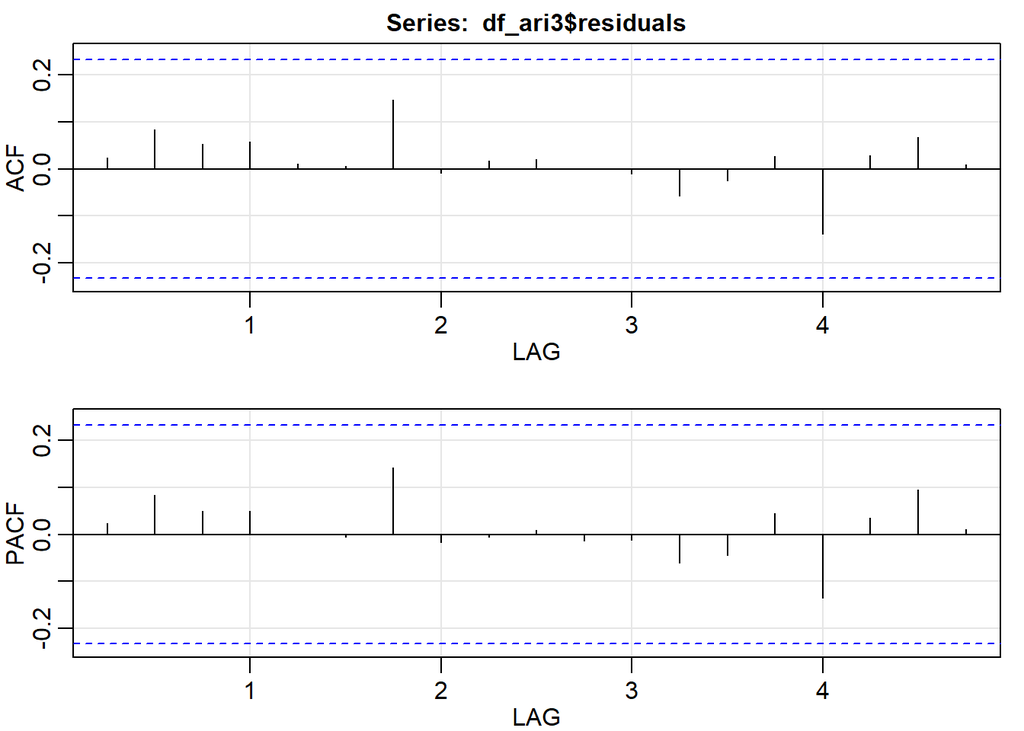

```
##         ACF  PACF
##  [1,]  0.02  0.02
##  [2,]  0.08  0.08
##  [3,]  0.05  0.05
##  [4,]  0.06  0.05
##  [5,]  0.01  0.00
##  [6,]  0.01  0.00
##  [7,]  0.15  0.14
##  [8,] -0.01 -0.02
##  [9,]  0.02 -0.01
## [10,]  0.02  0.01
## [11,]  0.00 -0.01
## [12,] -0.01 -0.01
## [13,] -0.06 -0.06
## [14,] -0.02 -0.04
## [15,]  0.03  0.04
## [16,] -0.14 -0.14
## [17,]  0.03  0.04
## [18,]  0.07  0.10
## [19,]  0.01  0.01
```

```r
acf2(df_ari3$residuals)
```

```r
Box.test(df_ari3$residuals, lag=12)
```

```
##
##  Box-Pierce test
##
## data:  df_ari3$residuals
## X-squared = 2.711, df = 12, p-value = 0.9973
```

```r
jarque.bera.test(df_ari3$residuals)
```

```
##
##  Jarque Bera Test
##
## data:  df_ari3$residuals
## X-squared = 85.15, df = 2, p-value < 2.2e-16
```

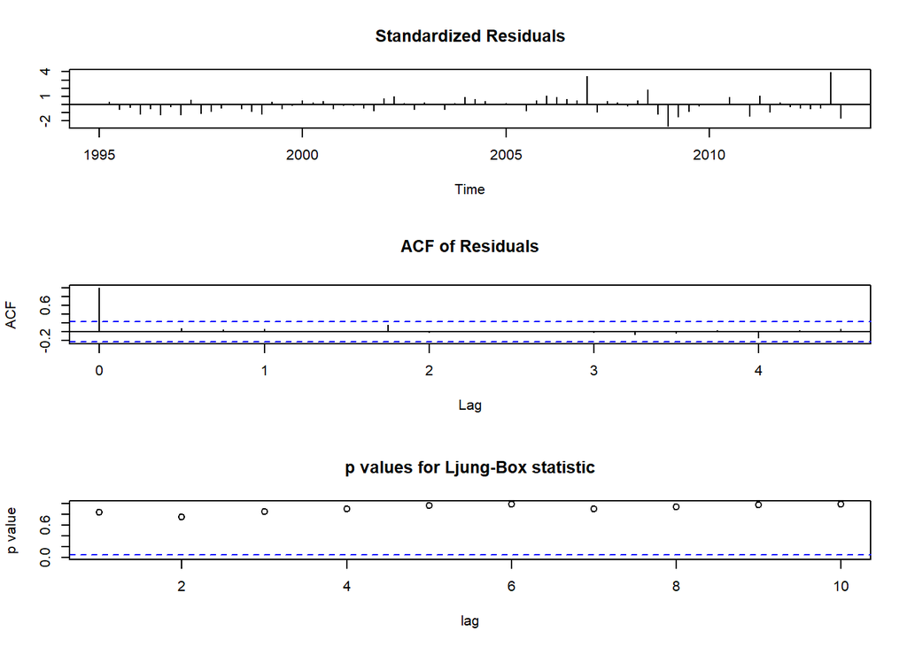

```r
tsdiag(df_ari3)
```

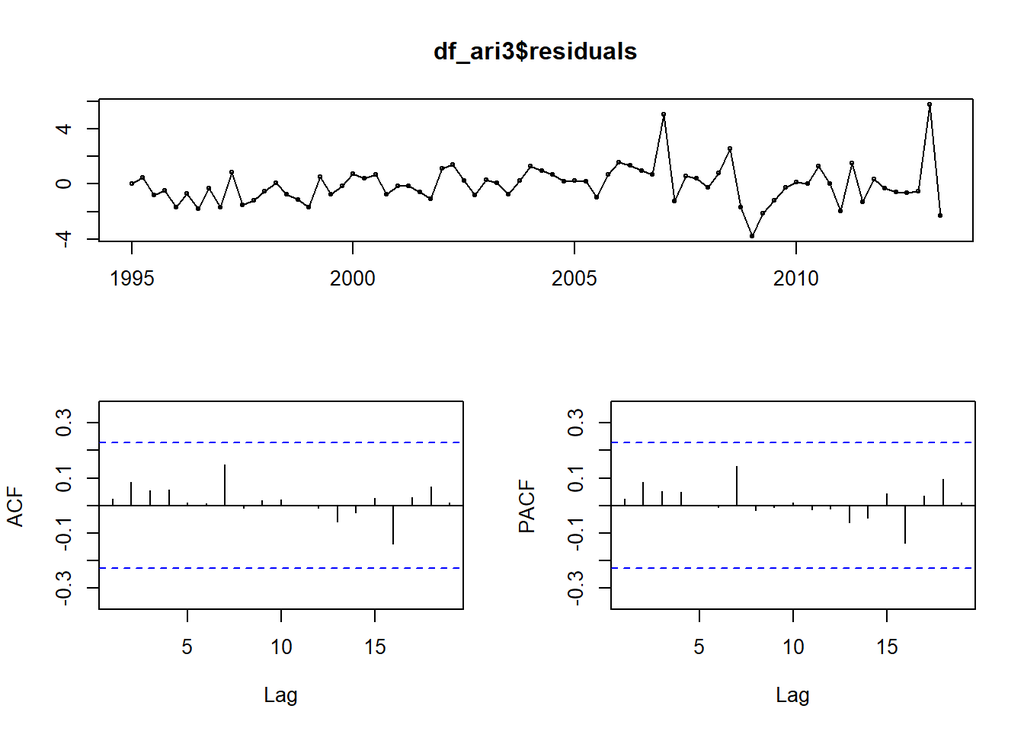

```r
tsdisplay(df_ari3$residuals)
```

## FORECAST

Since we have already discovered there might be an additive season component on our data we can do some forecast with ets model and with the “arima way”.

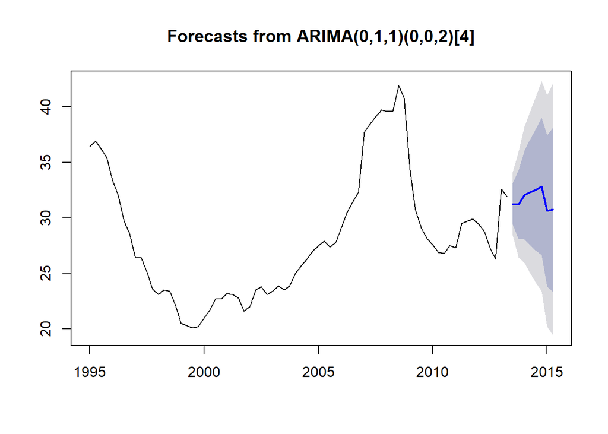

```r
plot(forecast(df_ari3))
```

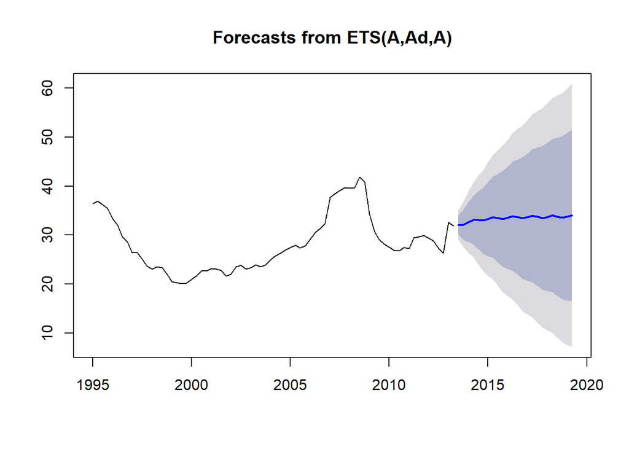

```r
df_ets = ets(df.ts, model = "AAA")
df_ets_f=forecast(df_ets,h=24)
plot(df_ets_f)
```

We can see that the grey? margins are bigger as the time goes by, which is a logical consequence from the increase of the uncertainty. From our point of view, the one that that seems more likely to happen is the first one since it introduces a kind of moody trend which is consequent with our true data. The ets model forecast a rather flat timeseries which may be perhaps a little bit unreal. But we are not sorcerers with powers to guess the future!!

Another utility we get for this is possibility of retrieving the exact value predicted from the model with a given certainty and we can see that they are consequent with the plots we got.

```r
forecast(df_ari3)
```

```
##         Point Forecast    Lo 80    Hi 80    Lo 95    Hi 95
## 2013 Q3       31.25738 29.40439 33.11036 28.42349 34.09127
## 2013 Q4       31.19621 28.07668 34.31574 26.42531 35.96712
## 2014 Q1       32.06297 28.05930 36.06663 25.93988 38.18605
## 2014 Q2       32.29607 27.57089 37.02124 25.06954 39.52259
## 2014 Q3       32.52528 27.04643 38.00413 24.14610 40.90446
## 2014 Q4       32.83886 26.65540 39.02232 23.38208 42.29564
## 2015 Q1       30.63414 23.81853 37.44975 20.21056 41.05771
## 2015 Q2       30.74608 23.35217 38.13999 19.43808 42.05409
```